# Exploratory Analysis of Conflict Data

## Exploratory Analysis of Conflict Data

## I. Dataset Overview

The dataset is an integration of:

1. **The Uppsala Conflict Data Program Data Files**: the world’s main provider of data on organized violence and armed conflicts. The files used are:
> - UCDP Georeferenced Event Dataset (GED) Global version 18.1
> - UCDP One-sided Violence Dataset
> - UCDP/PRIO Armed Conflict Dataset version 18.1
> - UCDP Dyadic Dataset version 18.1
> - UCDP Conflict Termination Dataset version 2-2015
1. **Non-State Actor Dataset**: provides information on the military capabilities and politicalopportunities available to non-state actors in on-going civil wars. It is a direct expansion of the Uppsala Armed Conflict Data.
2. **The Foundations of Rebel Group Emergence Dataset**: provides information on the origins of violent non-state actors engaged in armed conflict against their government. It draws upon the population of groups included in the Non-State Actor Dataset.

## II. Goal of Exploratory Analysis

The Uppsala Conflict Data Program conducted by the Uppsala University defines and provides data on three types of conflicts worldwide:

> 1. State-Based
> 2. Non-State Based
> 3. One-Sided Violence

The goal of this exploratory analysis is to understand trends in each of these three types of conflicts as well as worldwide conflicts in general. This includes:

> 1. Understanding the frequency of conflicts over time,
> 2. The actors directly and indirectly involved and
> 3. The variables effecting conflict outcomes.

## III. Gathering Data

```python
# import all packages and set plots to be embedded inline
import numpy as np
import pandas as pd
import matplotlib.pyplot as plt
import seaborn as sb
import os
import glob
%matplotlib inline

sb.set_style("whitegrid", {'axes.grid' : False})
plt.rcParams.update(plt.rcParamsDefault)
pd.set_option('display.max_columns',None)
```

```python
files=os.listdir('raw_data')
if os.path.exists('raw_data/.DS_Store'):
    os.remove('raw_data/.DS_Store')
```

```python
#read five files
files=os.listdir('raw_data')
id_mapping,ucdp_dyad_12,ucdp_onesided_18,ged191,ucdp_acd_18,forge,db,ucdp_nonstate_18,conflict_termination_15,ucdp_brd_18,ucdp_dyad_18,nsa,dyadid_mappings,ucdp_acd_12=[pd.read_excel(os.path.join('raw_data',f)) for f in files]
```

```python
#clean column headings
files=id_mapping,ucdp_dyad_12,ucdp_onesided_18,ged191,ucdp_acd_18,forge,db,ucdp_nonstate_18,conflict_termination_15,ucdp_brd_18,ucdp_dyad_18,nsa,dyadid_mappings,ucdp_acd_12
for f in files:
    f.columns=f.columns.str.lower().str.strip().str.replace(' ','_').str.replace(',','').str.replace('.','_')
```

## IV. Cleaning Data

### i. Clean and Merge NSA and Forge Datasets

```python
#drop columns referring to old ids in nsa
nsa.drop(nsa.columns[nsa.columns.str.contains('old')],axis=1,inplace=True)
```

```python
#create and rename columns for merging nsa with forge
nsa.rename(columns={'dyadid':'old_dyadid_12'},inplace=True)
forge.rename(columns={'nsadyadid':'old_dyadid_12'},inplace=True)

#merge nsa with forge db on dyad and fightyear
nsa_forge=nsa.merge(forge, how='left',on=['old_dyadid_12'])
```

```python
#dyadid 686 only ties to FLOSY in UCDP not NLF - drop NLF
nsa_forge_clean=nsa_forge.drop(214)
```

### ii. Merging NSA FORGE dataset with UCDP State Based Conflict dataset

```python
years=nsa_forge_clean[['startdate','enddate']].apply(lambda x:list(range(x[0].year,x[1].year +1)), axis=1)

nsa_forge_clean['duration']=years
temp=nsa_forge_clean[['obsid','duration']]
nsa_forge_clean['duration']=nsa_forge_clean['duration'].astype(str)




def explode(df, lst_cols, fill_value='', preserve_index=False):
    # make sure `lst_cols` is list-alike
    if (lst_cols is not None
        and len(lst_cols) > 0
        and not isinstance(lst_cols, (list, tuple, np.ndarray, pd.Series))):
        lst_cols = [lst_cols]
    # all columns except `lst_cols`
    idx_cols = df.columns.difference(lst_cols)
    # calculate lengths of lists
    lens = df[lst_cols[0]].str.len()
    # preserve original index values
    idx = np.repeat(df.index.values, lens)
    # create "exploded" DF
    res = (pd.DataFrame({
                col:np.repeat(df[col].values, lens)
                for col in idx_cols},
                index=idx)
             .assign(**{col:np.concatenate(df.loc[lens>0, col].values)
                            for col in lst_cols}))
    # append those rows that have empty lists
    if (lens == 0).any():
        # at least one list in cells is empty
        res = (res.append(df.loc[lens==0, idx_cols], sort=False)
                  .fillna(fill_value))
    # revert the original index order
    res = res.sort_index()
    # reset index if requested
    if not preserve_index:
        res = res.reset_index(drop=True)
    return res



durations=explode(temp,'duration', fill_value='')
durations.rename(columns={'duration':'year'},inplace=True)

nsa_forge_clean=nsa_forge_clean.merge(durations,how='left',on='obsid')
```

```python
#clean ucdp_dyad_18
ucdp_dyad_18.rename(columns={'dyad_id':'new_dyadid_18','conflict_id':'new_ucdpid_18'},inplace=True)

#map old dyad_id in nsa_forge to latest dyad_idds
dyadid_mappings=dyadid_mappings.query('type_of_violence==1')
ucdp_dyad_18=ucdp_dyad_18.merge(dyadid_mappings,how='left',on='new_dyadid_18')
```

```python
#merge nsa_forge_clean with ucdp_dyad_18
state_based=ucdp_dyad_18.merge(nsa_forge_clean, how='left', on=['old_dyadid_12','year'])

#multiple nsa entries for the same dyad-year if rebel characteristics change - keep earliest dyad-year drop later dyad-year
dup_state_based=state_based[state_based[['new_dyadid_18','old_dyadid_12','year']].duplicated()][['new_dyadid_18','old_dyadid_12','year']]
```

```python
state_based=state_based.drop(dup_state_based.index.unique())
```

```python
#update column names
state_based.rename(columns={'side_b_x':'side_b',
                               'side_b_y':'side_b_nsa','side_a_x':'side_a','side_a_y':'side_a_nsa'},inplace=True)
state_based.insert(0,'conflict_type','state_based')
```

### iii. Merge Conflict Termination dataset

```python
conflict_termination_15.columns=conflict_termination_15.columns.str.lower()
conflict_termination_15.rename(columns={'conflictid':'old_ucdpid_12','dyadid':'old_dyadid_12'},inplace=True)
```

```python
conflict_termination_15_copy=conflict_termination_15[['old_dyadid_12', 'year',  'outcome_early', 'outcome', 'cfiredate','peagdate']]
```

```python
state_based=state_based.merge(conflict_termination_15_copy,how='left',on=['old_dyadid_12', 'year'])
```

### iv. Merge Battle Related Deaths dataset

```python
ucdp_brd_18.rename(columns={'bd_best':'best_fatality_estimate','bd_low':'low_fatality_estimate','conflict_id':'new_ucdpid_18','dyad_id':'new_dyadid_18','bd_high':'high_fatality_estimate'},inplace=True)

ucdp_brd_18=ucdp_brd_18[['new_ucdpid_18', 'new_dyadid_18','year', 'best_fatality_estimate',
       'low_fatality_estimate', 'high_fatality_estimate', 'type_of_conflict']]
```

```python
state_based=state_based.merge(ucdp_brd_18,how='left',on=['new_ucdpid_18', 'new_dyadid_18','year'])
```

### v. Clean One-Sided Violence Dataset

```python
ucdp_onesided_18.insert(0,'conflict_type','onesided')
ucdp_onesided_18['side_a']=np.where(ucdp_onesided_18['is_government_actor']==1,ucdp_onesided_18['actor_name'],'--')
ucdp_onesided_18['side_b']=np.where(ucdp_onesided_18['is_government_actor']==0,ucdp_onesided_18['actor_name'],'--')
ucdp_onesided_18.drop(['actor_name','is_government_actor'],axis=1,inplace=True)
```

### vi. Clean Non-State Violence Dataset

```python
ucdp_nonstate_18.rename(columns={'side_a_name':'side_a','side_b_name':'side_b','ep_end_date':'enddate'},inplace=True)
ucdp_nonstate_18.insert(0,'conflict_type','nonstate_based')
```

### vii. Merge One-Sided Violence, Non-State and State-Based Conflict Datasets

```python
conflict_df=pd.concat([state_based,ucdp_nonstate_18,ucdp_onesided_18],sort=False)
```

```python
conflict_df_copy=conflict_df.copy()
```

```python
#decode region

conditions_region=[conflict_df['region']==1,conflict_df['region']==2,conflict_df['region']==3,conflict_df['region']==4,conflict_df['region']==5]
choices_region=['Europe','Middle East','Asia','Africa','Americas']
conflict_df_copy['region']=np.select(conditions_region,choices_region,'--')
```

```python
#decode religion

conditions_religion=[conflict_df['religion']==0,conflict_df['religion']==1,conflict_df['religion']==2,conflict_df['religion']==3,conflict_df['religion']==4,conflict_df['religion']==5,conflict_df['religion']==6,conflict_df['religion']==7,conflict_df['religion']==8,conflict_df['religion']==9,conflict_df['religion']==10]
choices_religion=['None','Catholic','Protestant','Orthodox','Other Christian',"Muslim (Sunni)","Muslim (Shia)","Muslim (undefined)", 'Hindu', 'Buddhist','Other']
conflict_df_copy['religion']=np.select(conditions_religion,choices_religion,'--')
```

```python
#decode incompatibility

conditions_incomp=[conflict_df['incompatibility']==1,conflict_df['incompatibility']==2,conflict_df['incompatibility']==3]
choices_incomp=['territory','government','territory_and_government']
conflict_df_copy['incompatibility']=np.select(conditions_incomp,choices_incomp,'--')
```

```python
#decode conflict type

conditions_type=[conflict_df['type']==1,conflict_df['type']==2,conflict_df['type']==3,conflict_df['type']==4,conflict_df['conflict_type']=='nonstate_based',conflict_df['conflict_type']=='onesided']
choices_type=['extrasystemic','interstate','internal','internationalized_internal','nonstate_based','onesided']
np.select(conditions_type,choices_type,'--')

conflict_df_copy['type']=np.select(conditions_type,choices_type,'--')
```

```python
#decode outcome_early

conditions_outcome_early=[conflict_df['outcome_early']==1,conflict_df['outcome_early']==2,conflict_df['outcome_early']==3,conflict_df['outcome_early']==4,conflict_df['outcome_early']==5,conflict_df['outcome_early']==6]
choices_outcome_early=['Peace Agreement','Ceasefire','Govt Won','Rebels Won','Low Activity','Actor Ceases to Exists']
conflict_df_copy['outcome_early']=np.select(conditions_outcome_early,choices_outcome_early,'--')


#decode outcome

conditions_outcome=[conflict_df['outcome']==1,conflict_df['outcome']==2,conflict_df['outcome']==3,conflict_df['outcome']==4,conflict_df['outcome']==5,conflict_df['outcome']==6]
choices_outcome=['Peace Agreement','Ceasefire','Govt Won','Rebels Won','Low Activity','Actor Ceases to Exists']
conflict_df_copy['outcome']=np.select(conditions_outcome,choices_outcome,'--')
```

```python
#fill non-territory conflicts with --

conflict_df_copy.territory=conflict_df_copy.territory.fillna('--')
```

```python
ged191.rename(columns={'conflict_new_id':'new_ucdpid_18','dyad_new_id':'new_dyadid_18'},inplace=True)
```

```python
#merge conflict_df with breakdown of battle deaths from ged


fatalities=ged191.groupby(['new_dyadid_18', 'new_ucdpid_18', 'year']).sum().reset_index()[['new_dyadid_18', 'new_ucdpid_18', 'year',  'deaths_a',
       'deaths_b', 'deaths_civilians', 'deaths_unknown']]
conflict_df_copy=conflict_df_copy.merge(fatalities,how='left',on=(['new_dyadid_18', 'new_ucdpid_18', 'year']))
```

```python
concat_country=ged191[['year', 'new_ucdpid_18','new_dyadid_18','dyad_name','conflict_name','country']].drop_duplicates().groupby(['year', 'new_ucdpid_18','dyad_name','conflict_name','new_dyadid_18'])['country'].apply(', '.join).reset_index()
```

```python
conflict_df_copy=conflict_df_copy.merge(concat_country,how='left', on =['year', 'new_ucdpid_18',
                                                       'new_dyadid_18'])
```

```python
conflict_df_copy=conflict_df_copy[['conflict_type',
 'new_dyadid_18','year',
 'dyad_name',
 'conflict_name',
 'side_a',
 'side_a_2nd',
 'side_b',
 'side_b_2nd',
 'incompatibility',
 'country', 'location',
 'territory','region',
 'intensity',
 'type',
 'start_date',
 'start_date2',
 'enddate',
 'ep_end','conflict_name','outcome_early', 'outcome', 'cfiredate','peagdate',
 'deaths_a',
 'deaths_b',
 'deaths_civilians',
 'deaths_unknown',
 'best_fatality_estimate',
 'low_fatality_estimate',
 'high_fatality_estimate',
 'org', 'new_ucdpid_18',
 'old_dyadid_12',
 'extraterritorial',
 'rebpolwing',
 'rebpolwinglegal',
 'rebestimate',
 'rebestlow',
 'rebesthigh',
 'rebstrength',
 'centcontrol',
 'strengthcent',
 'mobcap',
 'armsproc',
 'fightcap',
 'terrcont',
 'terrname',
 'effterrcont',
 'conflicttype',
 'transconstsupp',
 'rebextpart',
 'rebpresosts',
 'presname',
 'rebel_support',
 'rtypesup',
 'rsupname',
 'gov_support',
 'gtypesup',
 'gsupname',
 'govextpart',
 'type_of_termination',
 'victory_side',
 'prevactive',
 'prevact_ref',
 'foundloc',
 'foundyear','fightyear',
 'goalnominal',
 'goalindep',
 'goalauto',
 'goalrights',
 'goalrep',
 'goalchange',
 'goaldem',
 'goalother',
 'goalnote',
 'ideology',
 'ideolcom',
 'ideolleft',
 'ideolright',
 'ideolnat',
 'ideolanti',
 'ideolrel',
 'ideoloth',
 'ideolnote',
 'religious',
 'religion',
 'ethnic',
 'ethnicity',
 'preorg',
 'preorgno',
 'preorgreb',
 'preorgter',
 'preorgpar',
 'preorgmvt',
 'preorgyou',
 'preorglab',
 'preorgmil',
 'preorggov',
 'preorgfmr',
 'preorgrel',
 'preorgfor',
 'preorgref',
 'preorgeth',
 'preorgoth',
 'preorgname',
 'merger',
 'splinter',
 'splinterucdp']]
```

### viii. Identify and Impute Missing Values

#### 1. Missing Fatality Estimates

```python
state_based.query('best_fatality_estimate.isnull()',engine='python').best_fatality_estimate=state_based.query('best_fatality_estimate.isnull()',engine='python').rebestimate
```

```python
#impute missing best_fatality_estimate using intensity levels

conditions_fatality= [((conflict_df_copy['best_fatality_estimate'].isnull()) & (conflict_df_copy['intensity']==1)),((conflict_df_copy['best_fatality_estimate'].isnull()) & (conflict_df_copy['intensity']==2))]
choices_fatality=[25,1000]

best_fatality_est=np.select(conditions_fatality,choices_fatality,'--')
imputed_best_fatality=best_fatality_est[best_fatality_est!='--']



conflict_df_copy.loc[conflict_df_copy['best_fatality_estimate'].isnull() & conflict_df_copy['intensity'].notnull(),'best_fatality_estimate']=imputed_best_fatality
conflict_df_copy.loc[conflict_df_copy['low_fatality_estimate'].isnull() & conflict_df_copy['intensity'].notnull(),'low_fatality_estimate']=imputed_best_fatality

#set fatality estimates to float type
conflict_df_copy.best_fatality_estimate=conflict_df_copy.best_fatality_estimate.astype(float)

#decode intensity
conflict_df_copy['intensity']=np.where(conflict_df_copy['best_fatality_estimate']>=1000,'war','minor')
```

#### 2. Missing Countries

```python
#impute missing countries where conflict occured using location (contrary to codebook location is not specific to the country of the government side in the dyad)

conflict_df_copy.loc[(conflict_df_copy['country'].isnull()),'country']=conflict_df_copy.loc[(conflict_df_copy['country'].isnull()),'location']
```

#### 3. Missing Dyad Name

```python
#impute missing dyad names that are already defined in the ged191 database but were not mapped because ged191 begins at 1989

dyad_names=conflict_df_copy.query('dyad_name.notnull()',engine='python')[['new_dyadid_18','dyad_name']].drop_duplicates().reset_index(drop=True)

conflict_df_temp=conflict_df_copy.copy()

conflict_df_temp=conflict_df_temp.merge(dyad_names,how='left',on='new_dyadid_18')
update_index=conflict_df_temp.query('dyad_name_x.isnull() & dyad_name_y.notnull()',engine='python').index

conflict_df_copy.loc[update_index,['dyad_name']]=conflict_df_temp.loc[update_index,['dyad_name_y']].values
```

```python
#impute remaining dyad names by joining side a and side b for armed conflicts

conflict_df_copy.loc[(conflict_df_copy['dyad_name'].isnull()) & (conflict_df_copy['conflict_type']!="onesided" ),'dyad_name']=conflict_df_copy.query('dyad_name.isnull() & conflict_type!="onesided"',engine='python')[['side_a','side_b']].apply(' - '.join,axis=1)


#impute remaining dyad names by joining organized group with Civilians for onesided violence

conflict_df_copy.loc[(conflict_df_copy['dyad_name'].isnull()) & (conflict_df_copy['conflict_type']=="onesided") & (conflict_df_copy['side_a']!="--"),'dyad_name']=conflict_df_copy.query('dyad_name.isnull() & conflict_type=="onesided" & side_a!="--"',engine='python')['side_a'].apply(lambda x: "{}{}".format(x, ' - Civilians'))
conflict_df_copy.loc[(conflict_df_copy['dyad_name'].isnull()) & (conflict_df_copy['conflict_type']=="onesided") & (conflict_df_copy['side_b']!="--"),'dyad_name']=conflict_df_copy.query('dyad_name.isnull() & conflict_type=="onesided" & side_b!="--"',engine='python')['side_b'].apply(lambda x: "{}{}".format(x, ' - Civilians'))
```

```python
#impute missing names that are already defined in the ged191 database but were not mapped because ged191 begins at 1989



conflict_names=conflict_df_copy.query('conflict_name.notnull()',engine='python')[['new_ucdpid_18','conflict_name']].drop_duplicates()

conflict_df_temp_2=conflict_df_copy.copy()
conflict_df_temp_2=conflict_df_temp_2.merge(conflict_names,how='left',on='new_ucdpid_18')
update_index_2=conflict_df_temp_2.query('conflict_name_x.isnull() & conflict_name_y.notnull()',engine='python').index

conflict_df_copy.loc[update_index_2,'conflict_name'] =conflict_df_temp_2.loc[update_index_2,'conflict_name_y']
```

#### 4. Data Entry Errors

```python
#replace invalid rsupnames
conflict_df_copy['rsupname']=conflict_df_copy['rsupname'].replace(['.',"no",' ',np.nan],'None').values

conflict_df_copy['rsupname']=conflict_df_copy.rsupname.replace({'USA':'US','United States':'US','US \(military\)':'US','United Kingdom':'UK','USSR':'Russia','Soviet Union':'Russia','Russia \(military\)':'Russia'},regex=True).values

#make seperations uniform
conflict_df_copy['rsupname']=conflict_df_copy.rsupname.replace([',;',';'],',',regex=True).values

conflict_df_copy.rsupname=conflict_df_copy.rsupname.str.strip()

#replace invalid rsupnames
conflict_df_copy['gsupname']=conflict_df_copy['gsupname'].replace(['.',"no",' ',np.nan],'None').values
conflict_df_copy['gsupname']=conflict_df_copy.gsupname.replace({'USA':'US','United States':'US',"Other military support\: US":"US",'US \(military\)':'US','United Kingdom':'UK','USSR':'Russia','Soviet Union':'Russia','Russia \(military\)':'Russia'},regex=True).values

#make seperations uniform
conflict_df_copy['gsupname']=conflict_df_copy.gsupname.replace(';',',',regex=True).values

conflict_df_copy.gsupname=conflict_df_copy.gsupname.str.strip()



#replace similar territory names
conflict_df_copy.replace({'territory':{'Common Border': 'Common border','Croat':'Croatia'}},inplace=True)
```

```python
conflict_df_copy=conflict_df_copy.reset_index(drop=True)
```

```python
conflict_df_copy.to_csv('conflicts_ucdp.csv',index=False)
```

### What is the structure of your dataset?

> There are **1,221 conflicts** & **1,550 dyads** worldwide from 1946 to 2017 in the dataset. Conflicts are qualified as acts of organized violence pereptuated by and against the government of a state or an organized rebel group resulting in at least 25 battle-related deaths in a year. The dataset distinguishes three types of conflicts:
> 1. State-based: a contested incompatibility between two parties in which at least one of them is the government of a state since the end of World War II.
> 2. Non-state based: use of armed force between two organized armed groups neither of which is the government of a state
> 3. One-sided Violence: use of armed force by the government of a state or by a formally organized group against civilians.

### What is/are the main feature(s) of interest in your dataset?

Features captured by the dataset include:

1. Geographical characteristics of the confict.
2. Parties involved (i.e. governments and organized rebel groups).
3. Motivations for the conflict (e.g. territory disputes or regime change).
4. Capabilities of and external support for the parties directly involved.
5. Conflict intensity measured by estimated number of battle related deaths.

### What features in the dataset do you think will help support your investigation into your feature(s) of interest?

> Trends in fatality estimates, support from external parties and number of new conflicts versus the persistence of existing conflicts over time are the primary features of interest in this analysis. The effect of rebel ideology, goal, religious affiliation and external support on conflict outcomes as well as variations in the explicit outcome itself will also contribute to the understanding the ontological and temporal characteristics of conflicts.

## Univariate Exploration

#### 1. Aggregate Overview of the Various Conflict Types

> **Understand the distribution across and within the three types of conflicts:**  
> a) State-based  
> b) Non-state based  
> c) One-sided violence

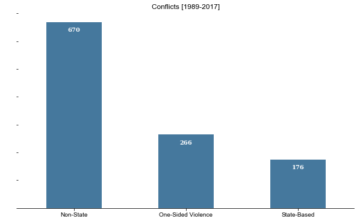

```python
#overall - conflict types
conflict_type=conflict_df_copy.query('year>=1989')[['conflict_type','new_ucdpid_18']].drop_duplicates()
conflict_type_order=conflict_type['conflict_type'].value_counts().index

fig, ax = plt.subplots(figsize=(10,6))
sb.set_style("whitegrid",{'axes.grid': False})
base_color = sb.color_palette("Blues_d")[2]
sb.countplot(data = conflict_type, x = 'conflict_type', color = base_color,order=conflict_type_order)
for bar in ax.patches:
    x = bar.get_x()
    width = bar.get_width()
    centre = x + width/2
    bar.set_x(centre - .5/2)
    bar.set_width(.5)


# add annotations
n_points = conflict_type.shape[0]
cat_counts = conflict_type['conflict_type'].value_counts()
locs, labels = plt.xticks() # get the current tick locations and labels


# loop through each pair of locations and labels
for loc, label in zip(locs, labels):

    # get the text property for the label to get the correct count
    count = cat_counts[label.get_text()]
    pct_string = count

    # print the annotation just below the top of the bar
    plt.text(loc, count-36, pct_string, ha = 'center', color = 'w',family='serif',size=10,weight='bold'
            )


ax.set(xlabel='', ylabel=' ',title='Conflicts [1989-2017]',yticklabels=[' '],xticklabels=["Non-State",'One-Sided Violence','State-Based']);
ax.spines['right'].set_visible(False)
ax.spines['top'].set_visible(False)
ax.spines['left'].set_visible(False)
```

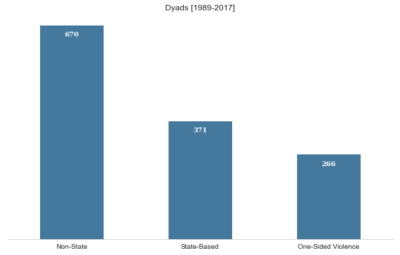

```python
#overall - dyad types
conflict_type=conflict_df_copy.query('year>=1989')[['conflict_type','new_dyadid_18']].drop_duplicates()
conflict_type_order=conflict_type['conflict_type'].value_counts().index

fig, ax = plt.subplots(figsize=(10,6))
sb.set_style("whitegrid",{'axes.grid': False})
base_color = sb.color_palette("Blues_d")[2]
sb.countplot(data = conflict_type, x = 'conflict_type', color = base_color,order=conflict_type_order)
for bar in ax.patches:
    x = bar.get_x()
    width = bar.get_width()
    centre = x + width/2
    bar.set_x(centre - .5/2)
    bar.set_width(.5)


# add annotations
n_points = conflict_type.shape[0]
cat_counts = conflict_type['conflict_type'].value_counts()
locs, labels = plt.xticks() # get the current tick locations and labels


# loop through each pair of locations and labels
for loc, label in zip(locs, labels):

    # get the text property for the label to get the correct count
    count = cat_counts[label.get_text()]
    pct_string = count

    # print the annotation just below the top of the bar
    plt.text(loc, count-36, pct_string, ha = 'center', color = 'w',family='serif',size=10,weight='bold'
            )


ax.set(xlabel='', ylabel='',title='Dyads [1989-2017]',yticklabels=[],xticklabels=["Non-State",'State-Based','One-Sided Violence']);
ax.spines['right'].set_visible(False)
ax.spines['top'].set_visible(False)
ax.spines['left'].set_visible(False)
```

```python
conflict_df_copy.query('year>=1989').new_ucdpid_18.nunique()
```

```
1112
```

**Overview of the Distribution Across the Three Types of Conflcits**:

> - Between 1989 and 2017 there have been 1307 dyads that roll up into 1112 conflicts.
> - The highest number of conflicts are non-state followed by one-sided violence and then state-based.
> - The highest number of dyads are non-state followed by state-based and then one-sided violence.

**Note:**

> While the dataset ranges from 1946-2017 only data for state based conflicts dates back to 1946. The recording of non-state and one-sided conflicts begins as of 1989. When the conflict is state based, the *conflict* is defined in terms of the state being targeted single while *dyads* take into account the second actor. For example, the Government of Bolivia has been involved in three dyads:
> 1. Government of Bolivia vs Popular Revolutionary Movement
> 2. Government of Bolivia vs MNR
> 3. Government of Bolivia vs ELN

> However, these *three dyads* are recorded as a *single conflict*. Conflicts are viewed through the lens of the targeted actor - in this case the Government of Bolivia  
> The number of dyads will therefore always exceed the number of conflicts in state based violence.

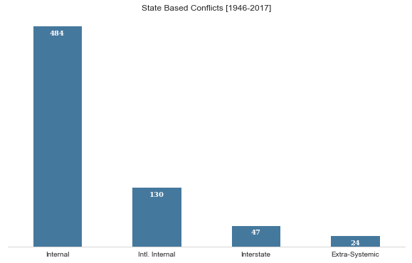

```python
#state based - conflict types summary
state_based_subtype=conflict_df_copy[['type','new_dyadid_18']].drop_duplicates().query('type!="onesided" & type!="nonstate_based"')
state_based_subtype_order=state_based_subtype['type'].value_counts().index

fig, ax = plt.subplots(figsize=(10,6))


#graph conflict subtypes
sb.countplot(data = state_based_subtype, x= 'type', color = base_color, order=state_based_subtype_order,ax=ax)
for bar in ax.patches:
    x = bar.get_x()
    width = bar.get_width()
    centre = x + width/2
    bar.set_x(centre - .5/2)
    bar.set_width(.5)

n_points = state_based_subtype.shape[0]
cat_counts = state_based_subtype['type'].value_counts()
locs, labels = plt.xticks() # get the current tick locations and labels


# loop through each pair of locations and labels
for loc, label in zip(locs, labels):

    # get the text property for the label to get the correct count
    count = cat_counts[label.get_text()]
    pct_string = count

    # print the annotation just below the top of the bar
    plt.text(loc, count-20, pct_string, ha = 'center', color = 'w',family='serif',size=10,weight='bold'
            )


ax.spines['right'].set_visible(False)
ax.spines['top'].set_visible(False)
ax.spines['left'].set_visible(False)


ax.set(ylabel='', xlabel='',title='State Based Conflicts [1946-2017]',yticklabels=[],xticklabels=["Internal",'Intl. Internal','Interstate','Extra-Systemic']);
plt.show()
```

**Distribution within State Based Conflicts**:

- Statistics for state-based conflicts date from 1946 to 2017. At an aggregate level, most state-based conflicts appear to be internal i.e. between a government and an organized rebel group.
- 130 state-based conflicts are international internal which are characterized as conflicts between a government and a rebel group that also includes the involvement of foreign government troops.
- There are 47 interstate conflicts rendering it the third most prominent state-based conflcit type. Interstate conflicts are conflicts fought between two recognized sovereign states.
- The least common state-based conflict category are extrasystemic conflicts with only 24 records in the databased. Extrasystemic conflicts are between a state and a non-state group outside its own territory, where the government side is fighting to retain control of a territory outside the state system.

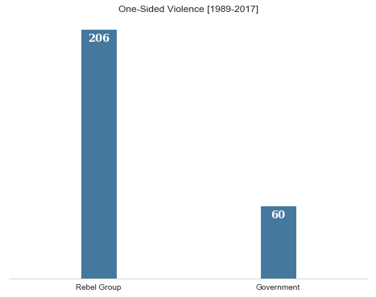

```python
#onesided - gov vs rebel involvement

onesided_conflict_subtype=conflict_df_copy.query('type=="onesided"')[['side_a','new_dyadid_18']].drop_duplicates()
onesided_conflict_subtype['onesided_type']=np.where(onesided_conflict_subtype['side_a']=='--',"Rebel Group","Government")
onesided_conflict_subtype_order=onesided_conflict_subtype['onesided_type'].value_counts().index


state_based_subtype=conflict_df_copy[['type','new_dyadid_18']].drop_duplicates().query('type!="onesided" & type!="nonstate_based"')
state_based_subtype_order=state_based_subtype['type'].value_counts().index

fig, ax = plt.subplots(figsize=(8,6))


#graph conflict subtypes
sb.countplot(data = onesided_conflict_subtype, x= 'onesided_type', color = base_color, order=onesided_conflict_subtype_order,ax=ax)
for bar in ax.patches:
    x = bar.get_x()
    width = bar.get_width()
    centre = x + width/2
    bar.set_x(centre - .2/2)
    bar.set_width(.2)

n_points = onesided_conflict_subtype.shape[0]
cat_counts = onesided_conflict_subtype['onesided_type'].value_counts()
locs, labels = plt.xticks() # get the current tick locations and labels


# loop through each pair of locations and labels
for loc, label in zip(locs, labels):

    # get the text property for the label to get the correct count
    count = cat_counts[label.get_text()]
    pct_string = count

    # print the annotation just below the top of the bar
    plt.text(loc, count-10, pct_string, ha = 'center', color = 'w',family='serif',size=13,weight='bold'
            )


ax.spines['right'].set_visible(False)
ax.spines['top'].set_visible(False)
ax.spines['left'].set_visible(False)


ax.set(ylabel='', xlabel='',title='One-Sided Violence [1989-2017]',yticklabels=[])
plt.show()
```

**Distribution within One-Sided Conflicts**:

- Statistics for one-sided conflicts date from 1989 to 2017. One-sided conflicts are carried out by the government of a state or an organized rebel group against civilians. In aggregate it appears the precipitation of one-sided violence is heavily skewed towards rebel groups over governments.

#### 2. State-Based Conflicts

With a preliminary understanding of the different types of conflicts I would like to take a closer look at state-based conflicts. This includes an exploration of the causes for conflict and the parties involved.

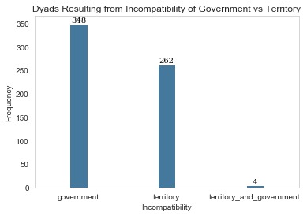

```python
#state based - incompatibility_type

fig,ax=plt.subplots()
incompatibility_type=conflict_df_copy[['incompatibility','new_dyadid_18']].drop_duplicates().query('incompatibility!="--"')
incompatibility_type_order=incompatibility_type['incompatibility'].value_counts().index

#graph conflict subtypes
sb.countplot(data = incompatibility_type, x= 'incompatibility', color = base_color, order=incompatibility_type_order)
ax.set(ylabel='Frequency', xlabel='Incompatibility',title='Dyads Resulting from Incompatibility of Government vs Territory');

for bar in ax.patches:
    x = bar.get_x()
    width = bar.get_width()
    centre = x + width/2
    bar.set_x(centre - .2/2)
    bar.set_width(.2)

n_points = incompatibility_type.shape[0]
cat_counts = incompatibility_type['incompatibility'].value_counts()
locs, labels = plt.xticks() # get the current tick locations and labels


# loop through each pair of locations and labels
for loc, label in zip(locs, labels):

    # get the text property for the label to get the correct count
    count = cat_counts[label.get_text()]
    pct_string = count

    # print the annotation just below the top of the bar
    plt.text(loc, count+4, pct_string, ha = 'center', color = 'black',family='serif'
            )
```

**Incompatibilities leading to State-Based Conflicts:**

> - State-based conflicts may arise as a result from an incompatibility between the two contesting parties (i.e. government of state or organized rebel groups). These incompatibilities may be the result of contention over the current political system or the control of a specific territory.
> - It appears that government incompatibilities have generated a majority of state-based conflicts at 348 dyads. This is followed by territory incompatibilities fueling 262 dyads and both territory and government incompatibilities contributing to 4 dyads.

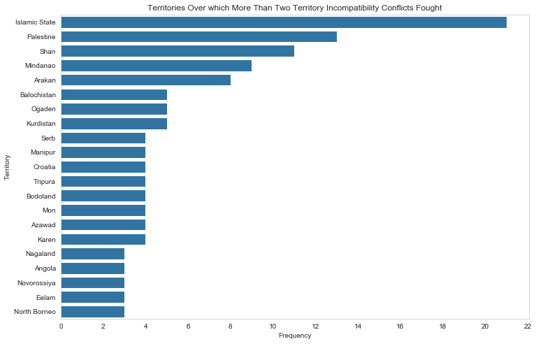

```python
#state based - disputed territories
disputed_territories=conflict_df_copy.query('territory!="--"  & territory!="Common border" & territory!="Various"  ')[['territory','new_dyadid_18']].drop_duplicates()
territories=disputed_territories.territory.value_counts().to_frame('frequency').query('frequency>2').reset_index().rename(columns={'index':'territory'})
disputed_territories_trimmed=disputed_territories.merge(territories.territory,how='inner',on='territory')
territories_order=disputed_territories_trimmed.territory.value_counts().index



fig, ax = plt.subplots(figsize = [12,8])

base_color = sb.color_palette()[0]
#graph conflict subtypes
sb.countplot(data =disputed_territories_trimmed, y = 'territory', color = base_color,order=territories_order)
ax.set(ylabel='Territory', xlabel='Frequency',title='Territories Over which More Than Two Territory Incompatibility Conflicts Fought',xticks=np.arange(0,24,2));
```

**Territory Incompatibilities:**

> - The 262 dyads motivated by territory incompatibilities stem from disputes over 138 unique territories.
> - Of these 138 territories, 21 territories have resulted in more than two dyads.
> - The Islamic State has provoked 21 dyads - the highest number across all territories - followed by Palestine at 13 and the Shan State at 11.
> - Contextualizing these territory disputes unveils a common theme of rebel groups vying for control over a territory under the sovereignty of an established government. The territories of major dispute indicate that claims over territory are often based on religious and ethnic grounds where minority groups rebel against the state for independence and secession. Mindanao and Palestine are prime examples of this are Palestine and Mindanao. Additionally, territorial incompatibilities may also result from rebellion against colonial rule like in the case of the Shan state.

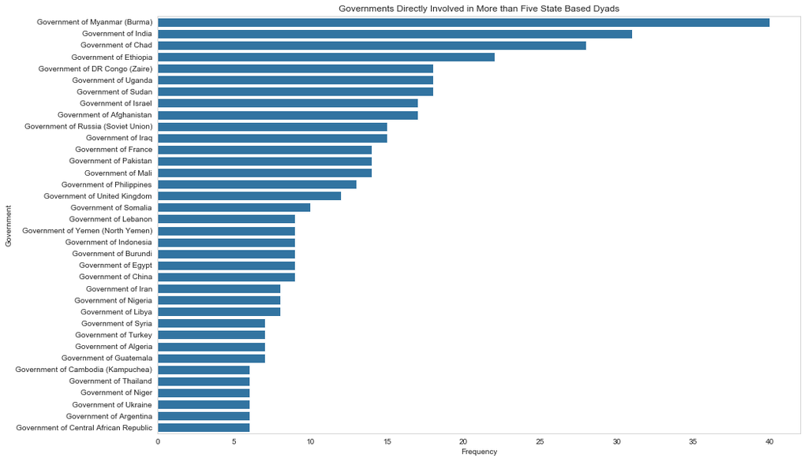

```python
#state based - governments involved frequency

government_a=conflict_df_copy.query('conflict_type=="state_based"')[['side_a','new_dyadid_18']].drop_duplicates()
government_a.rename(columns={'side_a':'government'},inplace=True)

government_b=conflict_df_copy.query('conflict_type=="state_based" & type=="interstate"')[['side_b','new_dyadid_18']]
government_b.rename(columns={'side_b':'government'},inplace=True)
gov_involvement=pd.concat([government_a,government_b])


gov_involvement=pd.DataFrame(gov_involvement.government.str.split(',').to_list(),index=gov_involvement.new_dyadid_18).stack().to_frame('government').reset_index().drop('level_1',axis=1).drop_duplicates()

gov_involvement=gov_involvement.groupby('government')['new_dyadid_18'].count().to_frame('frequency').reset_index()


gov_involvement_trimmed=gov_involvement.query('frequency>5')
gov_involvement_order=gov_involvement_trimmed.sort_values('frequency',ascending=False).government
fig,ax = plt.subplots(figsize = [15, 10])
base_color = sb.color_palette()[0]
sb.barplot(y=gov_involvement_trimmed.government, x=gov_involvement_trimmed.frequency, order=gov_involvement_order,color = base_color)
ax.set(ylabel='Government', xlabel='Frequency',title='Governments Directly Involved in More than Five State Based Dyads');
```

**Governments Directly Involved in More than Five State-Based Dyads:**

> - While there is only one conflict per government, a single government can engage in multiple dyads.
> - The Government of Myanmar has been involved in 40 dyads making it the government with the highest frequency of direct involvement in state-based dyads.
> - The Government of India comes second at 31 dyads followed by the Government of Chad at 28.

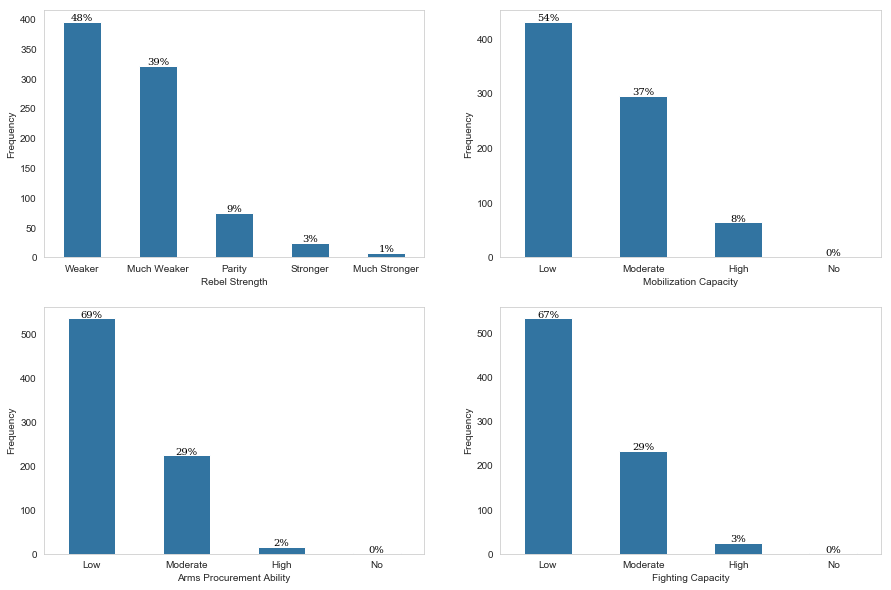

```python
#rebstrength
nsa_reb_strength=conflict_df_copy.query('rebstrength.notnull()',engine='python')[['rebstrength','outcome','new_dyadid_18']].drop_duplicates()
nsa_reb_strength_order=nsa_reb_strength.rebstrength.value_counts().index


#rebstrength
nsa_reb_mobcap=conflict_df_copy.query('mobcap.notnull()',engine='python')[['mobcap','outcome','new_dyadid_18']].drop_duplicates()
nsa_reb_mobcap_order=nsa_reb_mobcap.mobcap.value_counts().index

#rebstrength
nsa_reb_armsproc=conflict_df_copy.query('armsproc.notnull()',engine='python')[['armsproc','outcome','new_dyadid_18']].drop_duplicates()
nsa_reb_armsproc_order=nsa_reb_armsproc.armsproc.value_counts().index

#rebstrength
nsa_reb_fightcap=conflict_df_copy.query('fightcap.notnull()',engine='python')[['fightcap','outcome','new_dyadid_18']].drop_duplicates()
nsa_reb_fightcap_order=nsa_reb_fightcap.fightcap.value_counts().index


fig, ax = plt.subplots(2,2,figsize = [15,10])

base_color = sb.color_palette()[0]
#graph conflict subtypes
sb.countplot(data =nsa_reb_strength, x = 'rebstrength', color = base_color,order=nsa_reb_strength_order,ax=ax[0,0])
sb.countplot(data =nsa_reb_mobcap, x = 'mobcap', color = base_color,order=nsa_reb_mobcap_order,ax=ax[0,1])
sb.countplot(data =nsa_reb_armsproc, x = 'armsproc', color = base_color,order=nsa_reb_armsproc_order,ax=ax[1,0])
sb.countplot(data =nsa_reb_fightcap, x = 'fightcap', color = base_color,order=nsa_reb_fightcap_order,ax=ax[1,1])

xaxes_labels=['Rebel Strength','Mobilization Capacity','Arms Procurement Ability','Fighting Capacity']
reb_strength_df=[nsa_reb_strength,nsa_reb_mobcap,nsa_reb_armsproc,nsa_reb_fightcap]
xlabels=['rebstrength','mobcap','armsproc','fightcap']

for ax,xaxes,df,xlabel in zip(ax.flatten(),xaxes_labels,reb_strength_df,xlabels):

    for bar in ax.patches:
        x = bar.get_x()
        width = bar.get_width()
        centre = x + width/2.
        bar.set_x(centre - .5/2.)
        bar.set_width(.5)


    n_points = df.shape[0]

    cat_counts = df[xlabel].value_counts()
    locs = ax.get_xticks() # get the current tick locations and labels
    labels = ax.get_xticklabels()

    # loop through each pair of locations and labels
    for loc, label in zip(locs, labels):

        # get the text property for the label to get the correct count
        count = cat_counts[label.get_text()]


        pct_string = '{:0.0f}%'.format(100*count/n_points)

        # print the annotation just below the top of the bar
        ax.text(loc, count+2, pct_string, ha = 'center', color = 'black',family='serif',size=10
                )
    old_xticklabels = [item.get_text() for item in ax.get_xticklabels()]
    ax.set_xticklabels(labels=[x.title() for x in old_xticklabels])
    ax.set_ylabel('Frequency')
    ax.set_xlabel(xaxes)
```

**Distribution of Rebel Strength Relative to Government:**

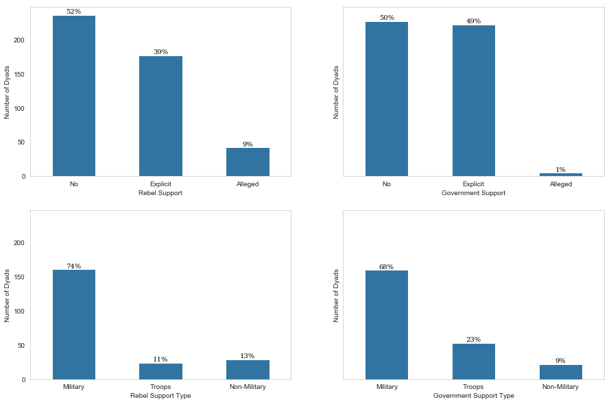

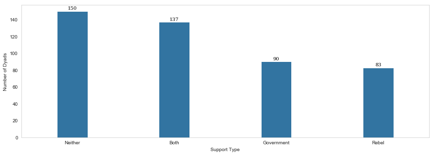

```python
#nsa_reb_support
nsa_reb_support=conflict_df_copy.query('rebel_support.notnull()',engine='python')[['rebel_support','new_dyadid_18']].drop_duplicates()
nsa_reb_support_order=nsa_reb_support.rebel_support.value_counts().index


#nsa_gov_support
nsa_gov_support=conflict_df_copy.query('gov_support.notnull()',engine='python')[['gov_support','new_dyadid_18']].drop_duplicates()
nsa_gov_support_order=nsa_gov_support.gov_support.value_counts().index


#nsa_rtypesup
nsa_rtypesup=conflict_df_copy.query('rtypesup.notnull()',engine='python')[['rtypesup','new_dyadid_18']].drop_duplicates()
nsa_rtypesup_order=nsa_rtypesup.rtypesup.value_counts().index


#nsa_rtypesup
nsa_gtypesup=conflict_df_copy.query('gtypesup.notnull()',engine='python')[['gtypesup','new_dyadid_18']].drop_duplicates()
nsa_gtypesup_order=nsa_gtypesup.gtypesup.value_counts().index




fig, ax = plt.subplots(2,2,figsize = [15,10],sharey=True)

base_color = sb.color_palette()[0]
#graph conflict subtypes
sb.countplot(data =nsa_reb_support, x = 'rebel_support', color = base_color,order=nsa_reb_support_order,ax=ax[0,0])
sb.countplot(data =nsa_gov_support, x = 'gov_support', color = base_color,order=nsa_gov_support_order,ax=ax[0,1])
sb.countplot(data =nsa_rtypesup, x = 'rtypesup', color = base_color,order=nsa_gtypesup_order,ax=ax[1,0])
sb.countplot(data =nsa_gtypesup, x = 'gtypesup', color = base_color,order=nsa_gtypesup_order,ax=ax[1,1])

xaxes_labels=['Rebel Support','Government Support','Rebel Support Type','Government Support Type']
support_df=[nsa_reb_support,nsa_gov_support,nsa_rtypesup,nsa_gtypesup]
xlabels=['rebel_support','gov_support','rtypesup','gtypesup']

for ax,xaxes,df,xlabel in zip(ax.flatten(),xaxes_labels,support_df,xlabels):
    for bar in ax.patches:
        x = bar.get_x()
        width = bar.get_width()
        centre = x + width/2.
        bar.set_x(centre - .5/2.)
        bar.set_width(.5)
    n_points = df.shape[0]

    cat_counts = df[xlabel].value_counts()
    locs = ax.get_xticks() # get the current tick locations and labels
    labels = ax.get_xticklabels()

    # loop through each pair of locations and labels
    for loc, label in zip(locs, labels):

        # get the text property for the label to get the correct count
        count = cat_counts[label.get_text()]

        pct_string = '{:0.0f}%'.format(100*count/n_points)

        # print the annotation just below the top of the bar
        ax.text(loc, count+2, pct_string, ha = 'center', color = 'black',family='serif',size=10)

    old_xticklabels = [item.get_text() for item in ax.get_xticklabels()]
    ax.set_xticklabels(labels=[x.title() for x in old_xticklabels])
    ax.set_ylabel('Number of Dyads')
    ax.set_xlabel(xaxes)




fig,ax=plt.subplots(figsize = [15,5])
conditions=[((conflict_df_copy['rebel_support']=="explicit") |
(conflict_df_copy['rebel_support']=="alleged")) &
((conflict_df_copy['gov_support']=="explicit") |
(conflict_df_copy['gov_support']=="alleged")),
    (conflict_df_copy['rebel_support']=="explicit") |
(conflict_df_copy['rebel_support']=="alleged") ,
(conflict_df_copy['gov_support']=="explicit") |
(conflict_df_copy['gov_support']=="alleged")]

choices=['Both','Rebel','Government']
external_support=conflict_df_copy.copy()
external_support['support']=np.select(conditions,choices,'Neither')
external_support=external_support.query('rebel_support.notnull()',engine='python')[['support','new_dyadid_18']].drop_duplicates()
sb.countplot(data =external_support, x = 'support', color = base_color)
ax.set(xlabel='Support Type',ylabel='Number of Dyads')
for bar in ax.patches:
    x = bar.get_x()
    width = bar.get_width()
    centre = x + width/2.
    bar.set_x(centre - .3/2.)
    bar.set_width(.3)


n_points = external_support.shape[0]

cat_counts = external_support['support'].value_counts()
locs = ax.get_xticks() # get the current tick locations and labels
labels = ax.get_xticklabels()

# loop through each pair of locations and labels
for loc, label in zip(locs, labels):

    # get the text property for the label to get the correct count
    count = cat_counts[label.get_text()]

    pct_string = count

    # print the annotation just below the top of the bar
    ax.text(loc, count+2, pct_string, ha = 'center', color = 'black',family='serif',size=10)
```

**Foreign Support for Rebels & Governments:**